# Modelos bayesianos de variables categóricas

Hector Najera

30/04/2026

# Introducción

Esta nota brinda una introducción bastante elemental a los siguientes tipos de modelos:

- Modelación de variables binarias
- Modelación de variables ordinales y nominales

También se aborda el cómputo de los estadísticos de validación cruzada: leave-one-out cross validation

```r
library(pacman)
p_load(haven, dplyr, brms, bayesplot, tidybayes, ggplot2)
color_scheme_set(scheme = "viridis")
```

Utilizaremos la siguiente base de datos en formato Stata.

```r
D<-read_dta("pobreza_18.dta")
head(D)
```

```
## # A tibble: 6 × 7
##   ictpc niv_edexpjh   ent tamhogesc tam_loc pobreza i_privacion
##   <dbl>       <dbl> <dbl>     <dbl> <chr>     <dbl>       <dbl>
## 1 7608.           1    12      1    1             0           2
## 2 1650.           0    12      1    2             1           1
## 3 9591.           2     5      8.37 2             0           0
## 4 2643.           1    18      1    1             0           0
## 5 6262.           4    32      2.73 1             0           1
## 6 2403.           2     6      3.72 4             0           1
```

# Modelo binario

Vamos a utilizar datos de la ENIGH 2018. Usaremos el nivel educativo, el tamaño del hogar y el de localidad como variables de ajuste. Además, ajustaremos el modelo por la entidad federativa de residencia.

$$\begin{aligned}
p_i &\sim \text{Bernoulli}(\mu_i) \\[6pt]
\text{logit}(\mu_i) &= \alpha + \sum_{k} \beta_k \,
\text{educ}_{k[i]}
+ \beta_{\text{tam}} \, \text{tamhogesc}_i
+ \sum_{j} \gamma_j \, \text{loc}_{j[i]} \\[6pt]
\alpha &\sim \mathcal{N}(0,\;5) \\
\beta_k &\sim \mathcal{N}(0,\;5) \\
\beta_{\text{tam}} &\sim \mathcal{N}(0,\;5) \\
\gamma_j &\sim \mathcal{N}(0,\;5)
\end{aligned}$$

donde:

- $p_i \in \{0, 1\}$: indicador de pobreza del hogar $i$
- $\mu_i$: probabilidad de pobreza
- $\alpha$: intercepto/ordenada al orígen (log-odds de pobreza en la categoría de referencia)
- $\beta_k$: efecto del nivel educativo $k$ del jefe de hogar
- $\beta_{\text{tam}}$: efecto del tamaño del hogar
- $\gamma_j$: efecto del tamaño de localidad $j$

> **Nota:** $\mathcal{N}(0, 5)$ en la escala log-odds es prácticamente una prior uniforme en probabilidades — permite valores extremos cercanos a 0 y 1.

## Chequeo a priori predictivo

```r
M_prior_weak <- brm(
  pobreza ~ 1 + factor(niv_edexpjh) + tamhogesc + factor(tam_loc),
  prior = c(
    set_prior("normal(0, 1000)", class = "b"),
    set_prior("normal(0, 1000)", class = "Intercept")  # explicit intercept prior
  ),
  family = bernoulli(),
  chains = 4, cores = 14,
  iter = 2000,
  threads = threading(14, grainsize = 100),
  backend = "cmdstanr",
  sample_prior = "only",   # <-- KEY: ignore data, sample from priors only
  data = D
)
```

[output not shown]

[output cut: 43 more lines]

[output not shown]

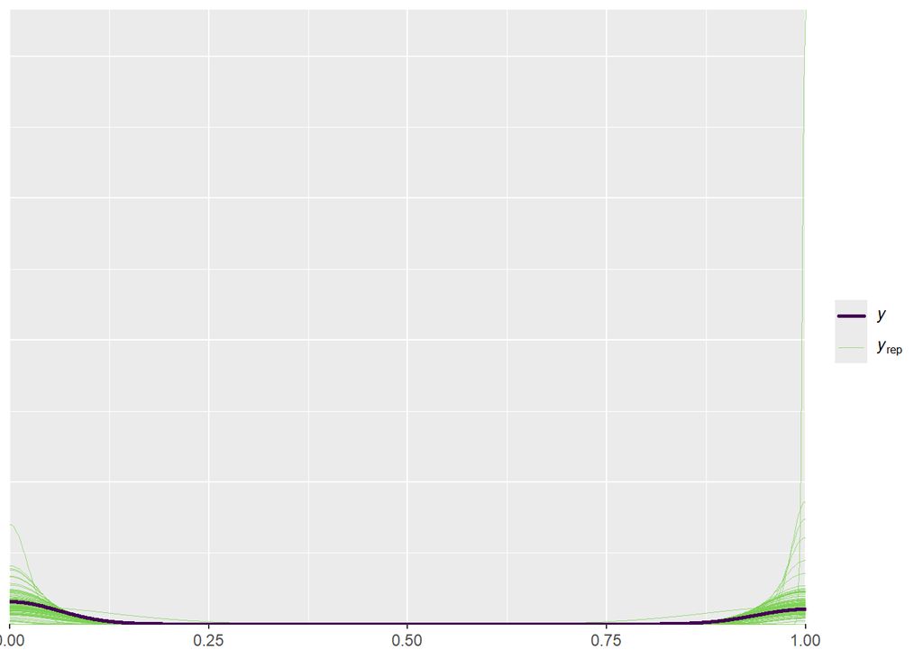

```r
pp_check(M_prior_weak, ndraws = 100)
```

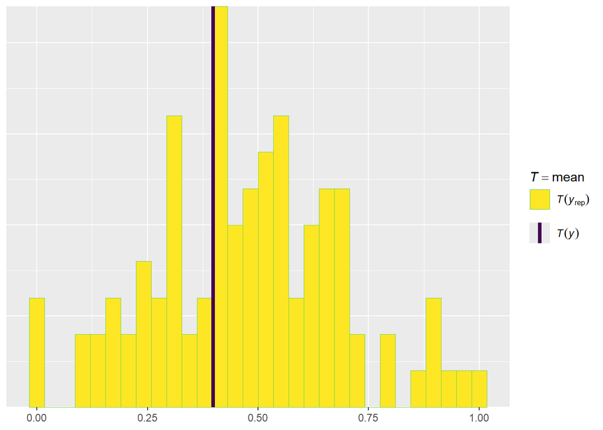

```r
pp_check(M_prior_weak, type = "stat", stat = "mean", ndraws = 100)
```

Ahora veremos qué pasa con a prioris débilmente informativos pero regularizadores

```r
M_prior_reg <- brm(
  pobreza ~ 1 + factor(niv_edexpjh) + tamhogesc + factor(tam_loc),
  prior = c(
    set_prior("normal(0, 5)", class = "b"),
    set_prior("normal(0, 5)", class = "Intercept")  # explicit intercept prior
  ),
  family = bernoulli(),
  chains = 4, cores = 14,
  iter = 2000,
  threads = threading(14, grainsize = 100),
  backend = "cmdstanr",
  sample_prior = "only",   # <-- KEY: ignore data, sample from priors only
  data = D
)
```

[output not shown]

[output cut: 43 more lines]

[output not shown]

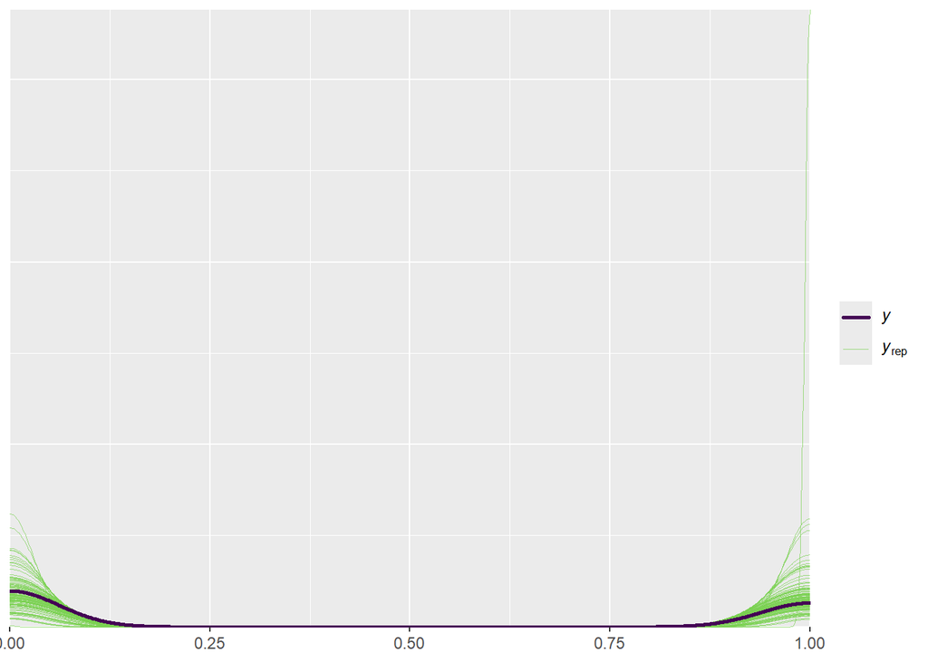

```r
pp_check(M_prior_reg, ndraws = 100)
```

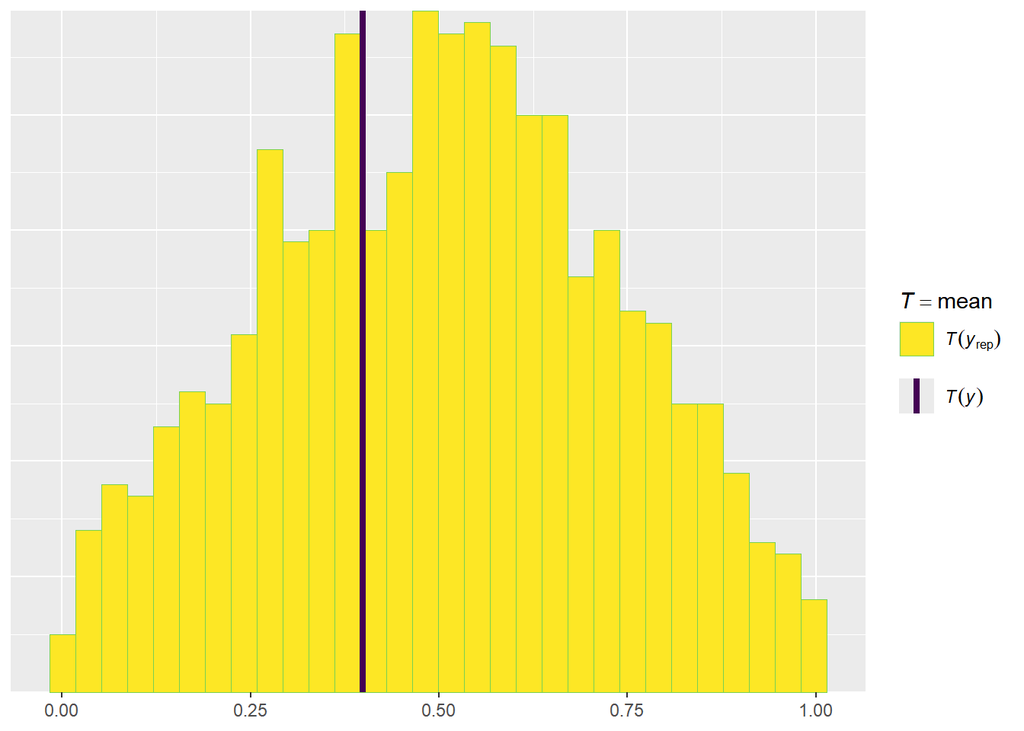

```r
pp_check(M_prior_reg, type = "stat", stat = "mean", ndraws = 1000)
```

## Estimación del modelo con priors regularizadores

```r
M<-brm(pobreza ~ 1 + factor(niv_edexpjh) + tamhogesc + factor(tam_loc),
        prior = c(set_prior("normal(0,5)", class = "b")),
        family="bernoulli",
        chains=4, cores=14,
        iter=2000,
        threads = threading(14, grainsize = 100),
        backend = "cmdstanr",
        data=D)
```

[output not shown]

[output cut: 43 more lines]

[output not shown]

```r
summary(M)
```

```
##  Family: bernoulli
##   Links: mu = logit
## Formula: pobreza ~ 1 + factor(niv_edexpjh) + tamhogesc + factor(tam_loc)
##    Data: D (Number of observations: 19999)
##   Draws: 4 chains, each with iter = 2000; warmup = 1000; thin = 1;
##          total post-warmup draws = 4000
##
## Regression Coefficients:
##                    Estimate Est.Error l-95% CI u-95% CI Rhat Bulk_ESS Tail_ESS
## Intercept             -0.70      0.06    -0.81    -0.59 1.00     4500     2811
## factorniv_edexpjh1    -0.35      0.04    -0.43    -0.27 1.00     4660     3681
## factorniv_edexpjh2    -0.75      0.04    -0.83    -0.67 1.00     4402     3322
## factorniv_edexpjh3    -1.39      0.06    -1.50    -1.28 1.00     5505     3138
## factorniv_edexpjh4    -2.44      0.09    -2.62    -2.27 1.00     5691     3669
## tamhogesc              0.14      0.01     0.12     0.15 1.00     8511     2933
## factortam_loc2         0.65      0.05     0.55     0.74 1.00     4603     2961
## factortam_loc3         0.96      0.05     0.87     1.06 1.00     4338     2928
## factortam_loc4         0.41      0.04     0.34     0.49 1.00     4158     3216
##
## Draws were sampled using sample(hmc). For each parameter, Bulk_ESS
## and Tail_ESS are effective sample size measures, and Rhat is the potential
## scale reduction factor on split chains (at convergence, Rhat = 1).
```

Agregamos variables

```r
M1<-brm(pobreza ~ 1 + factor(niv_edexpjh) + tamhogesc + factor(tam_loc) + factor(ent),
        prior = c(set_prior("normal(0,5)", class = "b")),
        family="bernoulli", chains=4, cores=14, iter=2000,  threads = threading(14, grainsize = 100),backend = "cmdstanr", data=D)
```

[output not shown]

[output cut: 43 more lines]

[output not shown]

```r
summary(M1)
```

```
##  Family: bernoulli
##   Links: mu = logit
## Formula: pobreza ~ 1 + factor(niv_edexpjh) + tamhogesc + factor(tam_loc) + factor(ent)
##    Data: D (Number of observations: 19999)
##   Draws: 4 chains, each with iter = 2000; warmup = 1000; thin = 1;
##          total post-warmup draws = 4000
##
## Regression Coefficients:
##                    Estimate Est.Error l-95% CI u-95% CI Rhat Bulk_ESS Tail_ESS
## Intercept             -1.36      0.11    -1.57    -1.14 1.02      232      587
## factorniv_edexpjh1    -0.29      0.05    -0.38    -0.20 1.00     2415     2983
## factorniv_edexpjh2    -0.65      0.04    -0.73    -0.56 1.00     2120     2506
## factorniv_edexpjh3    -1.40      0.06    -1.52    -1.28 1.00     2404     2690
## factorniv_edexpjh4    -2.50      0.09    -2.68    -2.33 1.00     3026     3058
## tamhogesc              0.14      0.01     0.12     0.16 1.00     4501     2770
## factortam_loc2         0.44      0.06     0.33     0.55 1.00     3011     2897
## factortam_loc3         0.67      0.05     0.57     0.78 1.00     2635     2868
## factortam_loc4         0.23      0.04     0.15     0.31 1.00     2334     3037
## factorent2            -0.22      0.13    -0.47     0.02 1.02      278      731
## factorent3            -0.19      0.14    -0.46     0.09 1.01      385      978
## factorent4             1.00      0.13     0.73     1.26 1.02      293     1147
## factorent5            -0.17      0.13    -0.43     0.08 1.02      261      990
## factorent6             0.45      0.13     0.20     0.69 1.02      285     1021
## factorent7             2.29      0.14     2.01     2.57 1.01      379     1108
## factorent8             0.45      0.12     0.22     0.68 1.02      292      865
## factorent9             0.60      0.14     0.33     0.86 1.02      304      840
## factorent10            0.63      0.13     0.38     0.88 1.02      257      838
## factorent11            0.84      0.12     0.60     1.07 1.02      257      856
## factorent12            1.89      0.14     1.61     2.15 1.01      374     1069
## factorent13            0.70      0.13     0.43     0.95 1.02      310     1061
## factorent14            0.08      0.14    -0.20     0.34 1.01      336      982
## factorent15            1.00      0.12     0.76     1.23 1.02      235      710
## factorent16            0.87      0.13     0.60     1.11 1.02      295      861
## factorent17            1.23      0.13     0.97     1.48 1.01      336      802
## factorent18            0.45      0.14     0.17     0.72 1.01      400     1100
## factorent19           -0.39      0.14    -0.67    -0.13 1.01      345     1264
## factorent20            1.82      0.14     1.54     2.08 1.02      346     1133
## factorent21            1.60      0.13     1.34     1.87 1.02      323     1058
## factorent22            0.13      0.12    -0.11     0.37 1.02      289      798
## factorent23            0.18      0.15    -0.12     0.47 1.01      440     1285
## factorent24            0.99      0.13     0.74     1.24 1.02      261      886
## factorent25            0.50      0.13     0.25     0.75 1.02      300      873
## factorent26            0.50      0.14     0.23     0.77 1.02      333     1464
## factorent27            1.53      0.14     1.26     1.79 1.02      291     1074
## factorent28            0.90      0.14     0.62     1.17 1.02      347     1068
## factorent29            1.02      0.13     0.76     1.29 1.02      317      982
## factorent30            1.76      0.13     1.49     2.00 1.01      306     1047
## factorent31            0.70      0.13     0.45     0.94 1.02      249      733
## factorent32            1.01      0.13     0.75     1.26 1.02      286      776
##
## Draws were sampled using sample(hmc). For each parameter, Bulk_ESS
## and Tail_ESS are effective sample size measures, and Rhat is the potential
## scale reduction factor on split chains (at convergence, Rhat = 1).
```

¿Incrementa Chiapas el riesgo de vivir en pobreza, relativo a Aguascalientes?

```r
get_variables(M1)
```

```
##  [1] "b_Intercept"          "b_factorniv_edexpjh1" "b_factorniv_edexpjh2"
##  [4] "b_factorniv_edexpjh3" "b_factorniv_edexpjh4" "b_tamhogesc"
##  [7] "b_factortam_loc2"     "b_factortam_loc3"     "b_factortam_loc4"
## [10] "b_factorent2"         "b_factorent3"         "b_factorent4"
## [13] "b_factorent5"         "b_factorent6"         "b_factorent7"
## [16] "b_factorent8"         "b_factorent9"         "b_factorent10"
## [19] "b_factorent11"        "b_factorent12"        "b_factorent13"
## [22] "b_factorent14"        "b_factorent15"        "b_factorent16"
## [25] "b_factorent17"        "b_factorent18"        "b_factorent19"
## [28] "b_factorent20"        "b_factorent21"        "b_factorent22"
## [31] "b_factorent23"        "b_factorent24"        "b_factorent25"
## [34] "b_factorent26"        "b_factorent27"        "b_factorent28"
## [37] "b_factorent29"        "b_factorent30"        "b_factorent31"
## [40] "b_factorent32"        "Intercept"            "lprior"
## [43] "lp__"                 "accept_stat__"        "treedepth__"
## [46] "stepsize__"           "divergent__"          "n_leapfrog__"
## [49] "energy__"
```

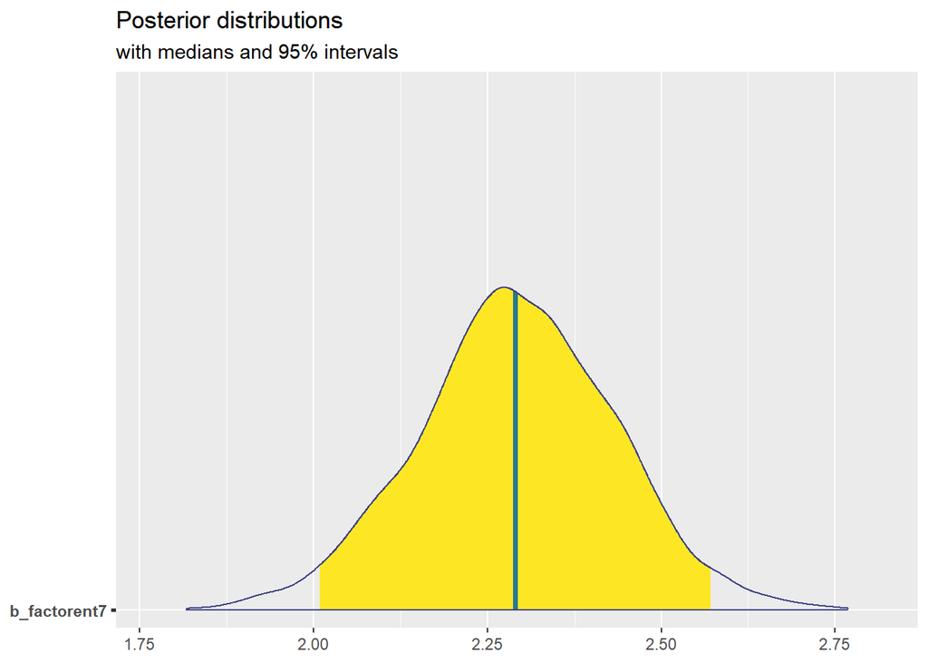

```r
plot_title <- ggtitle("Posterior distributions",
                      "with medians and 95% intervals")
mcmc_areas(M1,
           pars = c( "b_factorent7"),
           prob = 0.95) + plot_title
```

## Chequeos predictivos posteriores

Como puede apreciarse, el modelo hace un muy buen trabjo en predecir las proporciones de población pobre y no pobre.

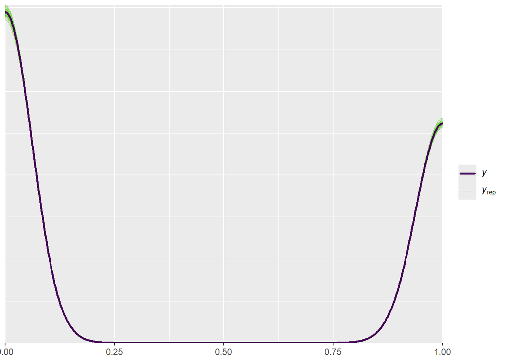

```r
pp_check(M1, ndraws = 100)
```

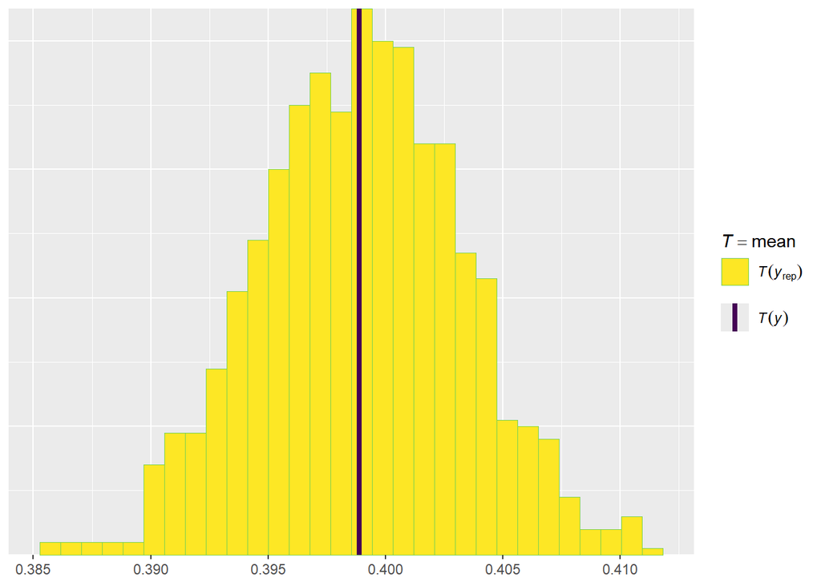

```r
pp_check(M1, type = "stat", stat = "mean", ndraws = 1000)
```

¿Cómo se compara con M?

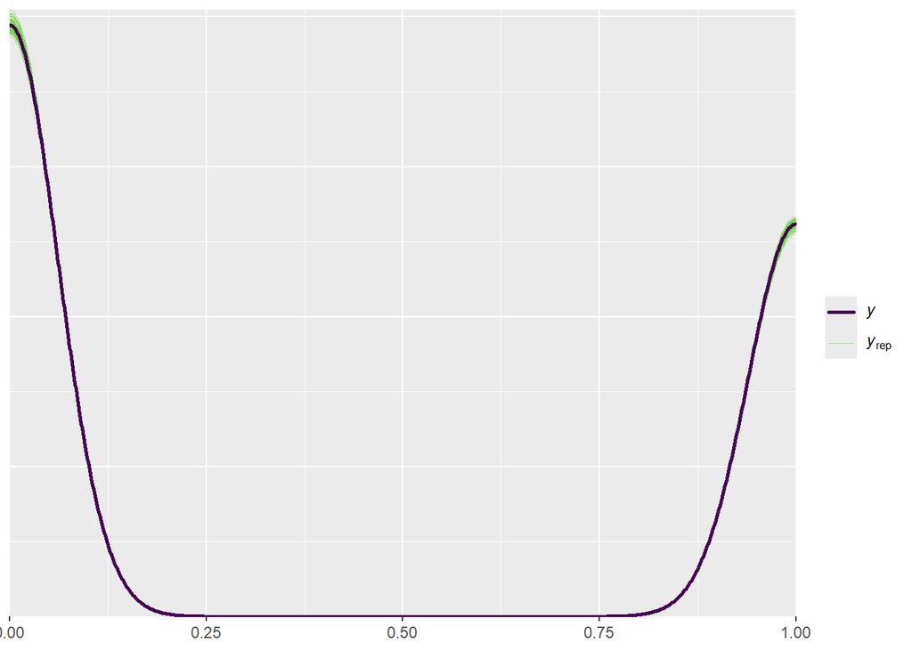

```r
pp_check(M, ndraws = 100)
```

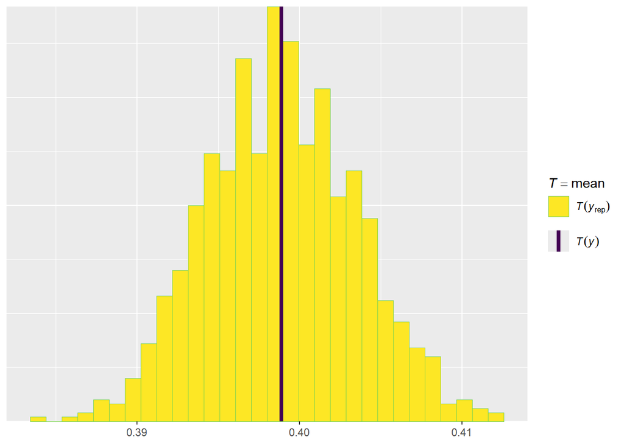

```r
pp_check(M, type = "stat", stat = "mean", ndraws = 1000)
```

## Compración de modelos: Validacion cruzada.

NOTA: El comando `loo` toma mucho tiempo. Modera tus expectativas. Abajo utilizamos una aproximación con `loo_subsample`.

*The Pareto k estimate is a diagnostic for Pareto smoothed importance sampling (PSIS), which is used to compute components of elpd_loo. In importance-sampling LOO (the full posterior distribution is used as the proposal distribution). The Pareto k diagnostic estimates how far an individual leave-one-out distribution is from the full distribution. If leaving out an observation changes the posterior too much then importance sampling is not able to give reliable estimate. If k<0.5, then the corresponding component of elpd_loo is estimated with high accuracy. If 0.5<k<0.7 the accuracy is lower, but still ok. If k>0.7, then importance sampling is not able to provide useful estimate for that component/observation. Pareto k is also useful as a measure of influence of an observation. Highly influential observations have high k values. **Very high k values often indicate model misspecification, outliers or mistakes in data processing.***

```r
M.loo<-loo(M)
M1.loo<-loo(M1)
M.loo
```

```
##
## Computed from 4000 by 19999 log-likelihood matrix.
##
##          Estimate    SE
## elpd_loo -12094.6  52.7
## p_loo         9.0   0.1
## looic     24189.2 105.3
## ------
## MCSE of elpd_loo is 0.0.
## MCSE and ESS estimates assume MCMC draws (r_eff in [0.9, 2.1]).
##
## All Pareto k estimates are good (k < 0.7).
## See help('pareto-k-diagnostic') for details.
```

```r
M1.loo
```

```
##
## Computed from 4000 by 19999 log-likelihood matrix.
##
##          Estimate    SE
## elpd_loo -11329.3  62.6
## p_loo        39.9   0.3
## looic     22658.6 125.3
## ------
## MCSE of elpd_loo is 0.1.
## MCSE and ESS estimates assume MCMC draws (r_eff in [0.0, 2.5]).
##
## All Pareto k estimates are good (k < 0.7).
## See help('pareto-k-diagnostic') for details.
```

`elpd` Expected Log Predictive Density. Más cercana a cero es mejor

`p_loo = 9.1` es el número efectivo de parámetros. Si se achica es buena señal (no hay sobreajuste)

`looic = 24189.3` es −2×elpd_loo-2

*When using loo_compare(), the returned matrix will have one row per model and several columns of estimates. The values in the elpd_diff and se_diff columns of the returned matrix are computed by making pairwise comparisons between each model and the model with the largest ELPD (the model in the first row). For this reason the elpd_diff column will always have the value 0 in the first row (i.e., the difference between the preferred model and itself) and negative values in subsequent rows for the remaining models.*

### LOO eficiente basado en n=400: loo_subsample

```r
fastloo<-loo_subsample(M)
fastloo1<-loo_subsample(M1)
```

K-pareto: Observaciones con influencia sobre la posterior

```r
fastloo1
```

```
##
## Computed from 4000 by 400 subsampled log-likelihood
## values from 19999 total observations.
##
##          Estimate    SE subsampling SE
## elpd_loo -11330.1  62.6            1.4
## p_loo        39.4   0.3            2.1
## looic     22660.2 125.2            2.7
## ------
## MCSE of elpd_loo is 0.0.
## MCSE and ESS estimates assume MCMC draws (r_eff in [0.0, 2.3]).
##
## All Pareto k estimates are good (k < 0.7).
## See help('pareto-k-diagnostic') for details.
```

Gráficas con loo

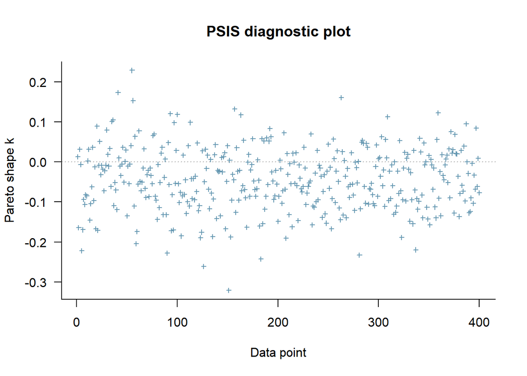

```r
plot(fastloo1)
```

Comparación de los modelos:

```r
loo_compare(fastloo1,fastloo)
```

```
##    elpd_diff se_diff subsampling_se_diff
## M1   0.0       0.0     0.0
## M  765.7      81.8     1.7
```

elpd_diff = 765.4 significa que M1 tiene 765.4 unidades mayores de elpd que M (Es mejor M1)

|elpd_diff| > 2 × se_diff = 765.4≫2×81.8=163.6 (El M1 es mucho mejor)

subsampling_se_diff es la incertidumbre asociada a `loo_subsample` (muy pequeña aquí)

# Predicción

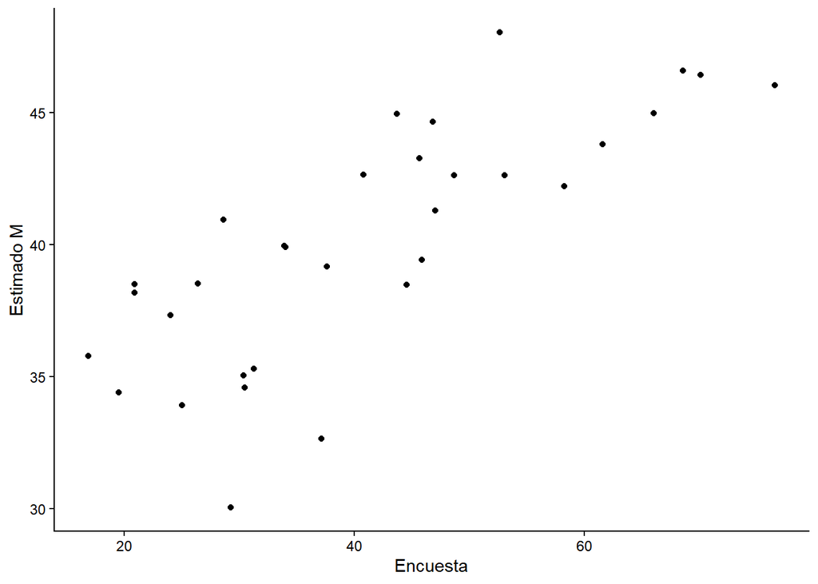

```r
D$prM<-predict(M, newdata=D ,ndraws=300)
D$prM1<-predict(M1, newdata=D ,ndraws=300)

D %>% group_by(ent) %>% summarise(SPent=mean(pobreza, na.rm=T), MPent=mean(prM[,1], na.rm=T),
                                  M1Pent=mean(prM1[,1], na.rm=T)) -> Prent

ggplot(Prent, aes(SPent*100, MPent*100)) + geom_point() + theme_classic() + labs(y="Estimado M", x="Encuesta")
```

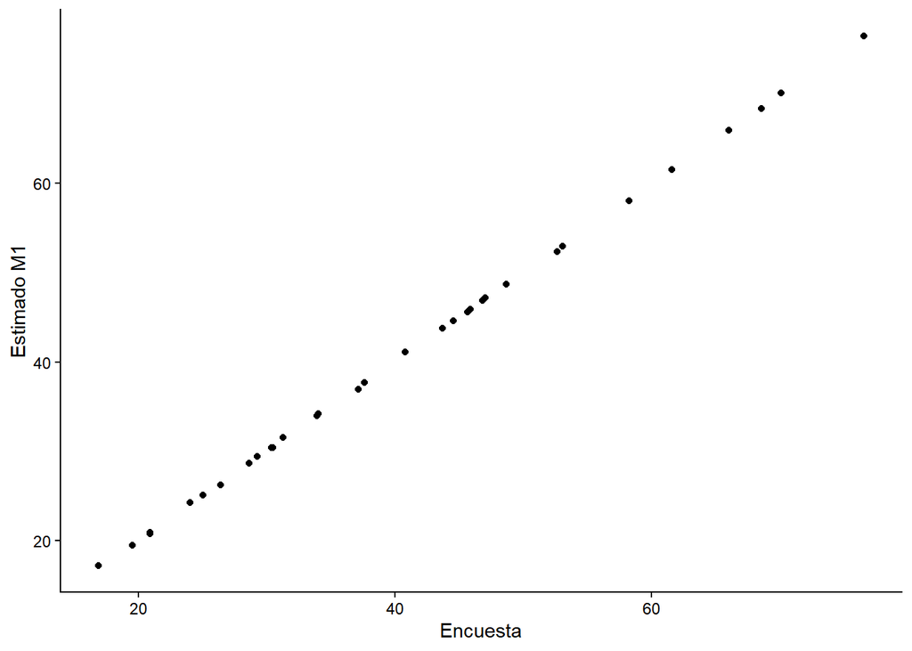

```r
ggplot(Prent, aes(SPent*100, M1Pent*100)) + geom_point() + theme_classic() + labs(y="Estimado M1", x="Encuesta")
```

# Segundo ejemplo: Ordinal v multinomial

Ahora vamos a model el score de carencias de la medición oficial. Este score va de 0 a 6 carencias. Esta variable es ordinal pero, como siempre en estos casos, no hay razones para pensar que los efectos sean proporcionales. Para poder modelar adecuadamente la variable con `brms`, tenemos que rescalar la variable para que vaya de 1 a 7. El modelo bayesiano se escribe a continuación:

$$\begin{aligned}
y_i &\sim \text{Ordered-logit}(\phi_i,\; \boldsymbol{\kappa})
\\[6pt]
\text{logit}\!\left[P(y_i \leq k)\right]
&= \kappa_k - \phi_i \quad \text{para } k = 1, \ldots, K-1
\\[6pt]
\phi_i &= \sum_{m} \beta_m \, \text{educ}_{m[i]}
+ \beta_{\text{tam}} \, \text{tamhogesc}_i
+ \sum_{j} \gamma_j \, \text{loc}_{j[i]}
+ \sum_{e} \delta_e \, \text{ent}_{e[i]} \\[6pt]
\kappa_k &\sim \mathcal{N}(0,\;
\text{student\_t}(3,0,2.5))
\quad \text{[default brms]} \\
\beta_m &\sim \mathcal{N}(0,\; 5) \\
\beta_{\text{tam}} &\sim \mathcal{N}(0,\; 5) \\
\gamma_j &\sim \mathcal{N}(0,\; 5) \\
\delta_e &\sim \mathcal{N}(0,\; 5)
\end{aligned}$$

donde:

- $y_i \in \{1, 2, \ldots, K\}$: índice de privación del hogar $i$
- $\phi_i$: predictor lineal (desplazamiento de los umbrales)
- $\kappa_k$: umbral $k$ — el log-odds acumulado en la categoría de referencia
- $K - 1$: número de umbrales (uno por cada corte entre categorías)
- `threshold = "flexible"`: cada umbral $\kappa_k$ se estima libremente

> **Interpretación de $\phi_i$:** un valor positivo de $\phi_i$ *desplaza* la distribución hacia categorías **más altas** de privación (más privación).

Para los modelos ordinales tenemos que cambiar a `cumulative("logit")`

```r
D$i_privacion1<-D$i_privacion+1

M2<-brm(i_privacion1 ~ 1 + factor(niv_edexpjh) + tamhogesc + factor(tam_loc) + factor(ent),
        prior = c(set_prior("normal(0,5)", class = "b")),
        family=cumulative("logit", threshold="flexible"),
        chains=2, cores=14, iter=2000,
        threads = threading(14, grainsize = 100),
        backend = "cmdstanr", data=D)
```

[output not shown]

```r
summary(M2)
```

```
##  Family: cumulative
##   Links: mu = logit; disc = identity
## Formula: i_privacion1 ~ 1 + factor(niv_edexpjh) + tamhogesc + factor(tam_loc) + factor(ent)
##    Data: D (Number of observations: 19999)
##   Draws: 2 chains, each with iter = 2000; warmup = 1000; thin = 1;
##          total post-warmup draws = 2000
##
## Regression Coefficients:
##                    Estimate Est.Error l-95% CI u-95% CI Rhat Bulk_ESS Tail_ESS
## Intercept[1]          -0.38      0.08    -0.54    -0.21 1.01      205      449
## Intercept[2]           1.23      0.08     1.07     1.39 1.01      203      402
## Intercept[3]           2.68      0.09     2.52     2.84 1.01      206      390
## Intercept[4]           4.08      0.09     3.91     4.26 1.01      219      366
## Intercept[5]           5.74      0.10     5.54     5.94 1.01      268      733
## Intercept[6]           7.77      0.17     7.45     8.14 1.00      644     1214
## factorniv_edexpjh1    -0.65      0.04    -0.72    -0.57 1.00      935     1448
## factorniv_edexpjh2    -1.11      0.04    -1.18    -1.04 1.00      897     1134
## factorniv_edexpjh3    -1.67      0.05    -1.76    -1.58 1.00      888     1195
## factorniv_edexpjh4    -2.22      0.06    -2.33    -2.10 1.00      999     1098
## tamhogesc              0.09      0.01     0.08     0.11 1.00     2055     1406
## factortam_loc2         0.35      0.04     0.26     0.43 1.00     1160     1404
## factortam_loc3         0.63      0.05     0.54     0.72 1.00     1158     1235
## factortam_loc4         1.07      0.04     1.00     1.14 1.00      831     1063
## factorent2             0.61      0.09     0.43     0.80 1.02      228      502
## factorent3             0.45      0.10     0.25     0.65 1.01      269      735
## factorent4             1.32      0.11     1.12     1.54 1.01      296      650
## factorent5             0.12      0.10    -0.07     0.31 1.01      264      346
## factorent6             0.78      0.10     0.58     0.96 1.01      242      546
## factorent7             1.88      0.11     1.67     2.09 1.01      260      503
## factorent8             0.65      0.09     0.47     0.83 1.01      211      543
## factorent9             1.10      0.11     0.89     1.30 1.01      294      612
## factorent10            0.30      0.10     0.11     0.49 1.01      249      577
## factorent11            0.69      0.10     0.50     0.86 1.01      232      373
## factorent12            2.13      0.10     1.93     2.33 1.01      250      659
## factorent13            0.85      0.11     0.64     1.07 1.01      265      560
## factorent14            0.69      0.10     0.49     0.89 1.01      248      550
## factorent15            0.95      0.09     0.76     1.13 1.01      218      511
## factorent16            1.03      0.11     0.82     1.24 1.01      268      617
## factorent17            1.25      0.11     1.04     1.45 1.01      261      549
## factorent18            0.73      0.11     0.51     0.95 1.01      275      625
## factorent19            0.16      0.10    -0.03     0.35 1.01      246      565
## factorent20            1.93      0.10     1.73     2.13 1.01      246      570
## factorent21            1.33      0.10     1.12     1.54 1.01      292      579
## factorent22            0.55      0.09     0.37     0.74 1.02      220      450
## factorent23            1.32      0.11     1.09     1.53 1.01      282      588
## factorent24            0.71      0.10     0.51     0.91 1.01      255      528
## factorent25            0.67      0.10     0.48     0.86 1.01      254      580
## factorent26            0.78      0.11     0.57     0.99 1.01      254      616
## factorent27            1.83      0.11     1.62     2.04 1.01      273      671
## factorent28            0.74      0.11     0.53     0.95 1.01      314      569
## factorent29            0.76      0.10     0.56     0.97 1.01      258      582
## factorent30            1.65      0.10     1.45     1.84 1.01      274      611
## factorent31            1.50      0.10     1.30     1.69 1.01      251      627
## factorent32            0.49      0.10     0.28     0.68 1.01      243      600
##
## Further Distributional Parameters:
##      Estimate Est.Error l-95% CI u-95% CI Rhat Bulk_ESS Tail_ESS
## disc     1.00      0.00     1.00     1.00   NA       NA       NA
##
## Draws were sampled using sample(hmc). For each parameter, Bulk_ESS
## and Tail_ESS are effective sample size measures, and Rhat is the potential
## scale reduction factor on split chains (at convergence, Rhat = 1).
```

En este caso `pp_check` lo hacemos con barras puesto que se trata de una variable de grupos

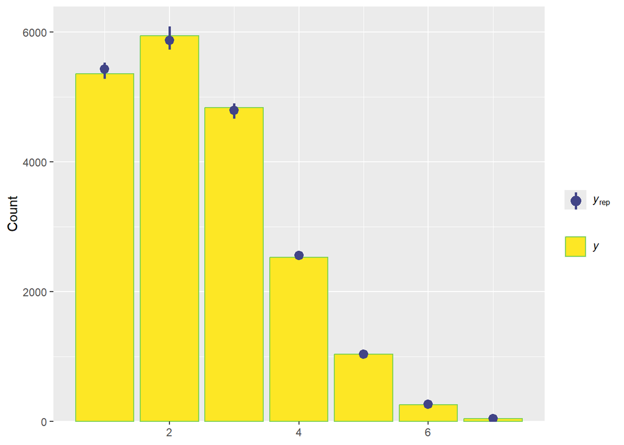

```r
pp_check(M2, nreps = 10, type = "bars")
```

# Multinomial

- Este modelo es más pesado: predictores X categorías con efectos aleatorios X categorías.
- Este modelo necesita prior débiles para producir resultados razonables.
- Intenten estimar este modelo con ML.

```r
D$i_privacion1<-as.factor(D$i_privacion1)
#Ds<-sample_n(D,10000)

M3<-brm(i_privacion1 ~ 1  + factor(niv_edexpjh) + tamhogesc + factor(tam_loc) + factor(ent),
         prior = c(set_prior("normal(0,5)", class="b", dpar = "mu2"),
                            set_prior("normal(0,5)", class="b", dpar = "mu3"),
                            set_prior("normal(0,5)", class="b", dpar = "mu4"),
                            set_prior("normal(0,5)", class="b", dpar = "mu5"),
                            set_prior("normal(0,5)", class="b", dpar = "mu6"),
                            set_prior("normal(0,5)", class="b", dpar = "mu7")),
        family = categorical(link = "logit"), chains=2, cores=2, iter=1500,  threads = threading(14, grainsize = 100),backend = "cmdstanr", data=D)
```

[output not shown]

Checamos la predicción

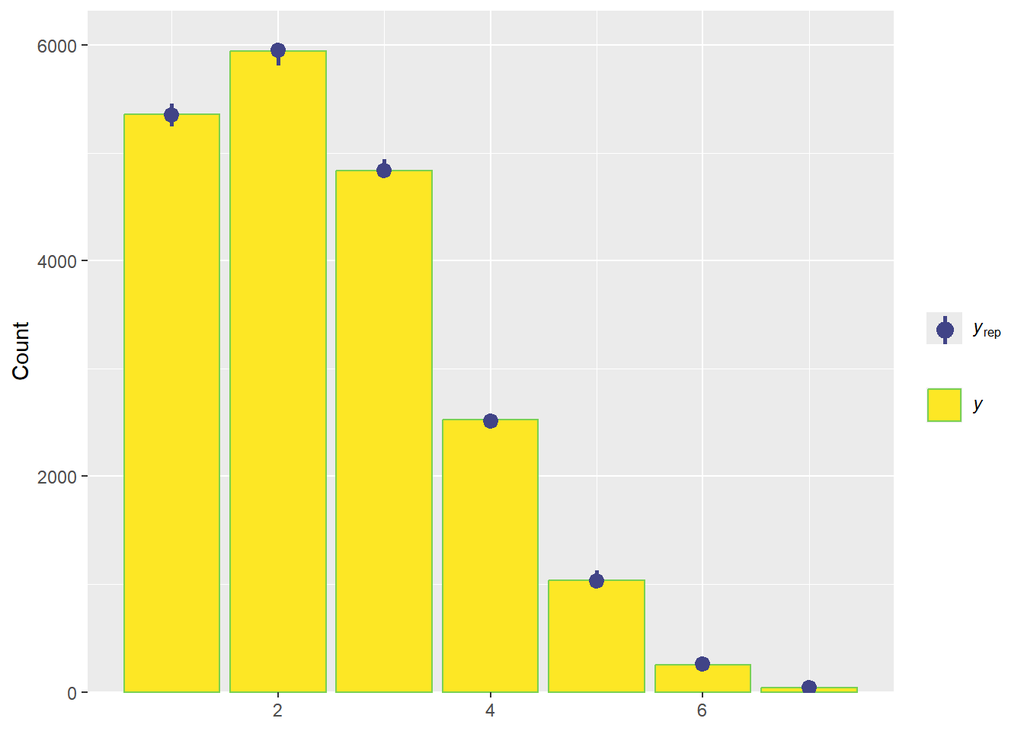

```r
pp_check(M3, nreps = 10, type = "bars")
```

¿Qué modelo es mejor el ordinal o el multinomial?

```r
M2.loo<-loo_subsample(M2)
M3.loo<-loo_subsample(M3)
M2.loo
```

```
##
## Computed from 2000 by 400 subsampled log-likelihood
## values from 19999 total observations.
##
##          Estimate    SE subsampling SE
## elpd_loo -27428.2  96.9            2.1
## p_loo        42.1   0.3            2.0
## looic     54856.3 193.9            4.2
## ------
## MCSE of elpd_loo is 0.0.
## MCSE and ESS estimates assume MCMC draws (r_eff in [0.1, 2.3]).
##
## All Pareto k estimates are good (k < 0.7).
## See help('pareto-k-diagnostic') for details.
```

```r
M3.loo
```

```
##
## Computed from 1500 by 400 subsampled log-likelihood
## values from 19999 total observations.
##
##          Estimate    SE subsampling SE
## elpd_loo -27455.9 105.1           98.3
## p_loo       403.3  17.9          125.0
## looic     54911.8 210.2          196.5
## ------
## MCSE of elpd_loo is NA.
## MCSE and ESS estimates assume MCMC draws (r_eff in [0.2, 2.0]).
##
## Pareto k diagnostic values:
##                           Count Pct.    Min. ESS
## (-Inf, 0.69]   (good)     399   99.8%   274
##    (0.69, 1]   (bad)        0    0.0%   <NA>
##     (1, Inf)   (very bad)   1    0.2%   <NA>
## See help('pareto-k-diagnostic') for details.
```

```r
loo_compare(M2.loo,M3.loo)
```

```
##    elpd_diff se_diff subsampling_se_diff
## M2   0.0       0.0     0.0
## M3  27.8     143.0    98.3
```

## Tarea: Checar cómo hacer predict para este tipo de modelos